# Project: Investigate a Dataset - The Movie Database (TMDb)

[figure not shown]

- Introduction
- Data Wrangling
- Exploratory Data Analysis
- Conclusions

## Introduction

> In this project, i'll be analyzing The Movie Database. Hundreds of movies are released every year but not all of them are profitable. The ojective of the project is to bring out insights from the TDMb dataset which have details about each movies such as revenue cost, budget, vote_count along with other informatoin.

### Question(s) for Analysis

1. What is the distribution of the data in the dataset
2. User Rating and Popularity
- How is the popularity of movie over the years
- How is the rating of movie over the years
- What is the relationship between Vote Count and Popularity
- What is the relationship between Vote Average and Popularity
- What is the relationship between Profit and Vote Average
- Months with most popular movie
- Which is the most popular genre
3. Monetary Analysis
- Which movie has the minimum and maximum Profit
- Which movie has the minimum and maximum Revenue
- Which movie has the minimum and maximum Budget
- Which movie has the minimum and maximum Return of Interest (ROI)
4. Monetary Visuals
- What is the relationship between Revenue, Budget and Profit
- What is the relationship between Revenue and Profit
- What is the relationship between Budget and Profit
- Which month has the highest profit from movie
- Which month has more movie produced
- What is the relationship between Runtime and Profit
- Top Budget Movie
- Top Revenue Movie

```python
#loading the required packages

import numpy as np
import pandas as pd
import matplotlib.pyplot as plt
%matplotlib inline
import seaborn as sns
sns.set_style('darkgrid')
```

## Data Wrangling

### General Properties

```python
#loading the data
db = pd.read_csv('tmdb-movies.csv')
db.head() #previewing
```

|  | id | imdb_id | popularity | budget | revenue | original_title | cast | homepage | director | tagline | ... | overview | runtime | genres | production_companies | release_date | vote_count | vote_average | release_year | budget_adj | revenue_adj |
| --- | --- | --- | --- | --- | --- | --- | --- | --- | --- | --- | --- | --- | --- | --- | --- | --- | --- | --- | --- | --- | --- |
| 0 | 135397 | tt0369610 | 32.985763 | 150000000 | 1513528810 | Jurassic World | Chris Pratt\|Bryce Dallas Howard\|Irrfan Khan\|Vi... | http://www.jurassicworld.com/ | Colin Trevorrow | The park is open. | ... | Twenty-two years after the events of Jurassic ... | 124 | Action\|Adventure\|Science Fiction\|Thriller | Universal Studios\|Amblin Entertainment\|Legenda... | 6/9/15 | 5562 | 6.5 | 2015 | 1.379999e+08 | 1.392446e+09 |
| 1 | 76341 | tt1392190 | 28.419936 | 150000000 | 378436354 | Mad Max: Fury Road | Tom Hardy\|Charlize Theron\|Hugh Keays-Byrne\|Nic... | http://www.madmaxmovie.com/ | George Miller | What a Lovely Day. | ... | An apocalyptic story set in the furthest reach... | 120 | Action\|Adventure\|Science Fiction\|Thriller | Village Roadshow Pictures\|Kennedy Miller Produ... | 5/13/15 | 6185 | 7.1 | 2015 | 1.379999e+08 | 3.481613e+08 |
| 2 | 262500 | tt2908446 | 13.112507 | 110000000 | 295238201 | Insurgent | Shailene Woodley\|Theo James\|Kate Winslet\|Ansel... | http://www.thedivergentseries.movie/#insurgent | Robert Schwentke | One Choice Can Destroy You | ... | Beatrice Prior must confront her inner demons ... | 119 | Adventure\|Science Fiction\|Thriller | Summit Entertainment\|Mandeville Films\|Red Wago... | 3/18/15 | 2480 | 6.3 | 2015 | 1.012000e+08 | 2.716190e+08 |
| 3 | 140607 | tt2488496 | 11.173104 | 200000000 | 2068178225 | Star Wars: The Force Awakens | Harrison Ford\|Mark Hamill\|Carrie Fisher\|Adam D... | http://www.starwars.com/films/star-wars-episod... | J.J. Abrams | Every generation has a story. | ... | Thirty years after defeating the Galactic Empi... | 136 | Action\|Adventure\|Science Fiction\|Fantasy | Lucasfilm\|Truenorth Productions\|Bad Robot | 12/15/15 | 5292 | 7.5 | 2015 | 1.839999e+08 | 1.902723e+09 |
| 4 | 168259 | tt2820852 | 9.335014 | 190000000 | 1506249360 | Furious 7 | Vin Diesel\|Paul Walker\|Jason Statham\|Michelle ... | http://www.furious7.com/ | James Wan | Vengeance Hits Home | ... | Deckard Shaw seeks revenge against Dominic Tor... | 137 | Action\|Crime\|Thriller | Universal Pictures\|Original Film\|Media Rights ... | 4/1/15 | 2947 | 7.3 | 2015 | 1.747999e+08 | 1.385749e+09 |

5 rows × 21 columns

> We've seen how the table looks like. The currency was not specified in the revenue or budget column, so we will assume it to be in dollars. Below we wil check the datatype for each column

> **Checking Datatype**

```python
# checking the datatype of each column
db.dtypes
```

```
id                        int64
imdb_id                  object
popularity              float64
budget                    int64
revenue                   int64
original_title           object
cast                     object
homepage                 object
director                 object
tagline                  object
keywords                 object
overview                 object
runtime                   int64
genres                   object
production_companies     object
release_date             object
vote_count                int64
vote_average            float64
release_year              int64
budget_adj              float64
revenue_adj             float64
dtype: object
```

> We've seen the data type for each column. After selecting the require column for the analysis the remaining column will be further investigated to be sure. Below we will check for duplicate rows

> **Checking for duplicates**

```python
#checking total duplicate
db.duplicated().sum()
```

```
1
```

```python
# we have only one duplicate,let's dig for more details
db[db.duplicated()]
```

|  | id | imdb_id | popularity | budget | revenue | original_title | cast | homepage | director | tagline | ... | overview | runtime | genres | production_companies | release_date | vote_count | vote_average | release_year | budget_adj | revenue_adj |
| --- | --- | --- | --- | --- | --- | --- | --- | --- | --- | --- | --- | --- | --- | --- | --- | --- | --- | --- | --- | --- | --- |
| 2090 | 42194 | tt0411951 | 0.59643 | 30000000 | 967000 | TEKKEN | Jon Foo\|Kelly Overton\|Cary-Hiroyuki Tagawa\|Ian... | NaN | Dwight H. Little | Survival is no game | ... | In the year of 2039, after World Wars destroy ... | 92 | Crime\|Drama\|Action\|Thriller\|Science Fiction | Namco\|Light Song Films | 3/20/10 | 110 | 5.0 | 2010 | 30000000.0 | 967000.0 |

1 rows × 21 columns

> From the above, we see that the row with id 42194 is a duplicate. This duplicate will be dropped in the data cleaning section.

> We will be generating a profit column from the revenue and budget column, thus let's wrangle both column for more details

> **Checking Properties of revenue and budget column**

```python
db.revenue.describe() #checking the properties of revenue column
```

```
count    1.086600e+04
mean     3.982332e+07
std      1.170035e+08
min      0.000000e+00
25%      0.000000e+00
50%      0.000000e+00
75%      2.400000e+07
max      2.781506e+09
Name: revenue, dtype: float64
```

```python
db.budget.describe() # checking the properties of budget column
```

```
count    1.086600e+04
mean     1.462570e+07
std      3.091321e+07
min      0.000000e+00
25%      0.000000e+00
50%      0.000000e+00
75%      1.500000e+07
max      4.250000e+08
Name: budget, dtype: float64
```

> Fom the above we can seen that 50% of the data is filled with zero (0) values, thus cannot help in generating profit. In the next section we will delete all rows with zero value in revenue and budget column.

> **Unwanted row**

> Some column are not needed to answer the questions for analysis. The below listed column will be dropped.

```python
# list of unwanted col
Unwanted_col =['id', 'imdb_id', 'homepage', 'tagline', 'keywords', 'overview', 'production_companies','budget_adj','revenue_adj']
```

### Data Cleaning

> **Dropping duplicates and unwanted row**

```python
#dropping duplicates
db.drop_duplicates(inplace=True)
db.duplicated().sum() # confirming that there is no duplicate.
```

```
0
```

```python
# remove unwanted row
db = db.drop(Unwanted_col, axis =1)
db.head(2) # previewing
```

|  | popularity | budget | revenue | original_title | cast | director | runtime | genres | release_date | vote_count | vote_average | release_year |
| --- | --- | --- | --- | --- | --- | --- | --- | --- | --- | --- | --- | --- |
| 0 | 32.985763 | 150000000 | 1513528810 | Jurassic World | Chris Pratt\|Bryce Dallas Howard\|Irrfan Khan\|Vi... | Colin Trevorrow | 124 | Action\|Adventure\|Science Fiction\|Thriller | 6/9/15 | 5562 | 6.5 | 2015 |
| 1 | 28.419936 | 150000000 | 378436354 | Mad Max: Fury Road | Tom Hardy\|Charlize Theron\|Hugh Keays-Byrne\|Nic... | George Miller | 120 | Action\|Adventure\|Science Fiction\|Thriller | 5/13/15 | 6185 | 7.1 | 2015 |

> **Dropping rows with zeros (0) in revenue and budget column**

```python
#dropping zero row in revenue and budget column
db_rev_0 = db.query('revenue == 0') # creating dataframe for revenue with with zero
db_bud_0 = db.query('budget == 0') # creating dataframe for budget with zero value.
db_rev_0.shape, db_bud_0.shape #showing the initial shape for later verification
```

```
((6016, 12), (5696, 12))
```

```python
col_0 = ['revenue','budget'] #creating a list of column
db[col_0] = db[col_0].replace(0,np.NaN) #replacing zero with NaN using np.NaN
db.dropna(subset=col_0, inplace=True) # dropping the replaced NaN from the dataframe.
```

```python
# rechecking for confirmation
db_bud_0 = db.query('budget == 0')
db_rev_0 = db.query('revenue == 0')
db_rev_0.shape, db_bud_0.shape
```

```
((0, 12), (0, 12))
```

> **Checking Datatype for Revenue, Budget and Release date**

```python
# further investigation on the revenue and budget datatype before creating profit column
type(db.revenue[0]),type(db.budget[0])
```

```
(numpy.float64, numpy.float64)
```

```python
# converting both column to "int" datatype
db.revenue = db.revenue.astype(int)
db.budget = db.budget.astype(int)

db.revenue[0].dtype, db.budget[0].dtype #checking for confrimation
```

```
(dtype('int64'), dtype('int64'))
```

```python
# changing release date data type to date format
db.release_date = pd.to_datetime(db.release_date)

db.head(2) #previewing
```

|  | popularity | budget | revenue | original_title | cast | director | runtime | genres | release_date | vote_count | vote_average | release_year |
| --- | --- | --- | --- | --- | --- | --- | --- | --- | --- | --- | --- | --- |
| 0 | 32.985763 | 150000000 | 1513528810 | Jurassic World | Chris Pratt\|Bryce Dallas Howard\|Irrfan Khan\|Vi... | Colin Trevorrow | 124 | Action\|Adventure\|Science Fiction\|Thriller | 2015-06-09 | 5562 | 6.5 | 2015 |
| 1 | 28.419936 | 150000000 | 378436354 | Mad Max: Fury Road | Tom Hardy\|Charlize Theron\|Hugh Keays-Byrne\|Nic... | George Miller | 120 | Action\|Adventure\|Science Fiction\|Thriller | 2015-05-13 | 6185 | 7.1 | 2015 |

> **Creating Profit and Return of Interest (ROI) column**

```python
# Creating the profit column
db.insert(3, 'profit', db.revenue - db.budget)
# Creating the return of interest column(ROI) column
db.insert(4, 'roi', db.profit / db.budget)
db.head(2) # Previewing
```

|  | popularity | budget | revenue | profit | roi | original_title | cast | director | runtime | genres | release_date | vote_count | vote_average | release_year |
| --- | --- | --- | --- | --- | --- | --- | --- | --- | --- | --- | --- | --- | --- | --- |
| 0 | 32.985763 | 150000000 | 1513528810 | 1363528810 | 9.090192 | Jurassic World | Chris Pratt\|Bryce Dallas Howard\|Irrfan Khan\|Vi... | Colin Trevorrow | 124 | Action\|Adventure\|Science Fiction\|Thriller | 2015-06-09 | 5562 | 6.5 | 2015 |
| 1 | 28.419936 | 150000000 | 378436354 | 228436354 | 1.522909 | Mad Max: Fury Road | Tom Hardy\|Charlize Theron\|Hugh Keays-Byrne\|Nic... | George Miller | 120 | Action\|Adventure\|Science Fiction\|Thriller | 2015-05-13 | 6185 | 7.1 | 2015 |

> **Creating a function that split a column that has pipe ('|')**

```python
# a function to split column having a pipe (|) as a sepearator
def split(col):
    details = db[col].str.cat(sep='|')
    content = pd.Series(details.split('|'))

    return content

a = split('director')
a.value_counts()
```

```
Steven Spielberg    28
Clint Eastwood      24
Ridley Scott        21
Woody Allen         18
Tim Burton          17
                    ..
Gurinder Chadha      1
Joel Zwick           1
Steve Beck           1
Lorna Cook           1
Howard Hawks         1
Length: 1785, dtype: int64
```

## Exploratory Data Analysis

### 1. What is the distribution of the data

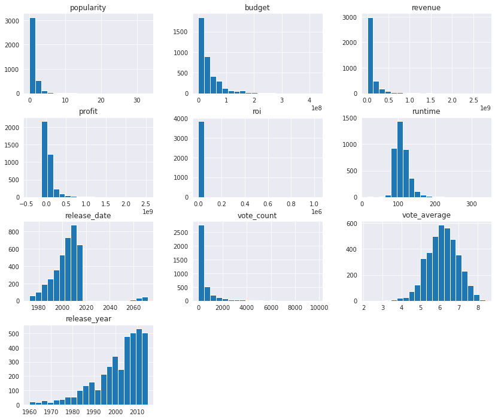

```python
db.hist(bins=20,figsize=(14,12));
```

### 2. User Rating and Popularity

> **How is the popularity of movie over the years**

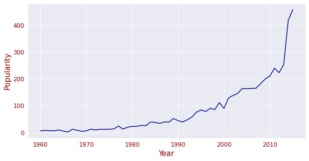

```python
#groupby release year
pop = db.groupby('release_year')['popularity'].sum()

#plotting populalarity over years
plt.figure(figsize=(10,5)) #setting figure size
plt.xlabel('Year', fontsize = 15, color='DarkRed') #setting horizotal label
plt.ylabel('Popularity', fontsize = 15, color='Darkred') #setting veertical label
plt.plot(pop,color='DarkBlue') #plotting a line chart
plt.tick_params(labelsize=12, labelcolor='DarkRed'); #setting the tick parameters
```

> Obviously movie popularity has ben increasing as the year goes by and there was a great increase between 2010 and 2015

> **How is the rating of movie over the years**

[figure not shown]

```python
#groupby release year
pop = db.groupby('release_year')['vote_average'].count()

#plotting populalarity over years
plt.figure(figsize=(10,5)) #setting figure size
plt.xlabel('Year', fontsize = 15, color='DarkRed') #setting horizotal label
plt.ylabel('Vote Average', fontsize = 15, color='Darkred') #setting veertical label
plt.plot(pop,color='DarkBlue') #plotting a line chart
plt.tick_params(labelsize=12, labelcolor='DarkRed'); #setting the tick parameters
```

> **What is the relationship between Vote Count and Popularity**

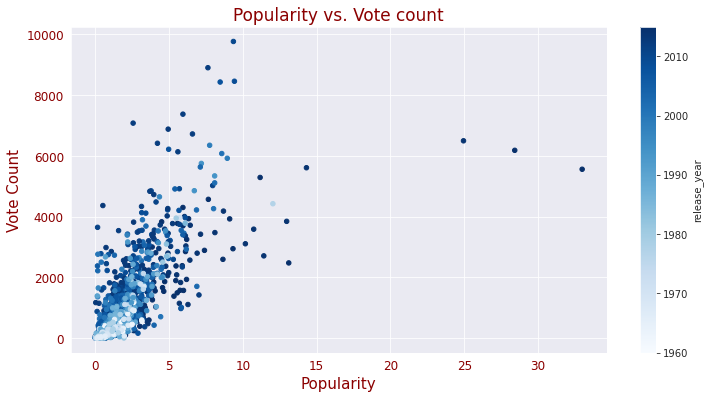

```python
#plotting scatter chart for visual
vpy = db.plot.scatter(x='popularity', y='vote_count',c='release_year',cmap='Blues',figsize=(12,6),sharex=False)
vpy.set_title('Popularity vs. Vote count', color='DarkRed', fontsize=17) #naming title
vpy.set_xlabel('Popularity', color='DarkRed',fontsize=15) #naming horizontal axis
vpy.set_ylabel('Vote Count', color='DarkRed',fontsize=15) #naming vertical axis
vpy.tick_params(labelsize=12, labelcolor='DarkRed'); #setting tick parammeters for both axis
```

> **What is the relationship between Vote Average and Popularity**

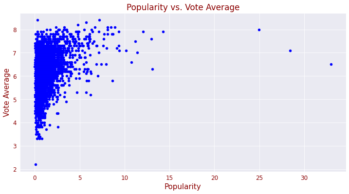

```python
#plotting scatter chart for visual
vp = db.plot.scatter(x='popularity', y='vote_average',c='Blue',figsize=(12,6))
vp.set_title('Popularity vs. Vote Average', color='DarkRed', fontsize=17) #naming title
vp.set_xlabel('Popularity', color='DarkRed',fontsize=15) #naming horizontal axis
vp.set_ylabel('Vote Average', color='DarkRed',fontsize=15) #naming vertical axis
vp.tick_params(labelsize=12, labelcolor='DarkRed'); #setting tick parameters
```

> If you check the plot above, you will notice that the movie with the highest rating is not popular.so we ca say popularity is not dependent on vote average

> **What is the relationship between Profit and Vote Average**

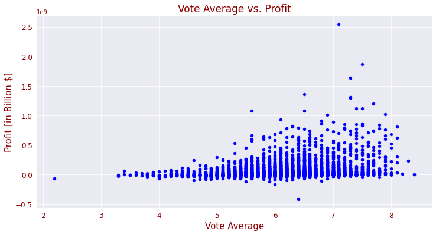

```python
#plotting scatter chart for visual
pv = db.plot.scatter(x='vote_average', y='profit',c='Blue',figsize=(12,6))
pv.set_title('Vote Average vs. Profit', color='DarkRed', fontsize=17) #naming title
pv.set_xlabel('Vote Average', color='DarkRed',fontsize=15) #naming horizontal axis
pv.set_ylabel('Profit [in Billion $]', color='DarkRed',fontsize=15) #naming vertical axis
pv.tick_params(labelsize=12, labelcolor='DarkRed'); #setting tick parameters
```

> Many will think that movie highly rated do make a lot of profit but from the plot above, the profit made by the highest rated movie is not up to the average profit made from movie.

> **Months with most popular movie**

```python
#creating a new dataframe to further explore the popularity for each month
dbv1 = db.set_index('release_date') # making release date our index
#selecting our month from date for grouping
month_num = dbv1.index.month
#grouping by month then summing the popularity for each month
month_pop = dbv1.groupby(month_num)['popularity'].sum()
#converting to dataframe
month_pop=pd.DataFrame(month_pop)
month_pop.head(3) #previewing
```

| release_date | popularity |
| --- | --- |
| 1 | 217.488302 |
| 2 | 244.911636 |
| 3 | 349.869740 |

```python
#making a list of month
month_names =['January', "February", 'March', 'April', 'May', 'June', 'July', 'August', 'September', 'October', 'November', 'December' ]
```

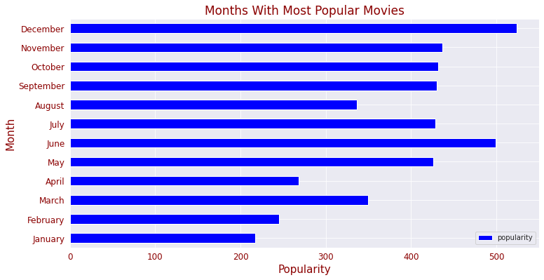

```python
#plotting horizontal bar chart for visual
mp= month_pop.plot.barh(y='popularity',rot=0,color='Blue',figsize=(12,6))
mp.set_title('Months With Most Popular Movies', color='DarkRed',fontsize=17) #naming title
mp.set_xlabel('Popularity',color='DarkRed', fontsize=15) #naming horizontal axis
mp.set_ylabel('Month', color='DarkRed', fontsize=15) #naming vertical axis
mp.tick_params(labelsize=12, labelcolor='DarkRed') #setting tick parameters for both axis
mp.set_yticklabels(month_names,); #naming vertical ticks with month names
```

> Movie gets popular in June and December. January happens to have lower movie popularity.

> **Which is the most popular genre**

> To get the most popular genre, we'll be going through some steps as seen below to achiecve this.

```python
dbv2 = db.copy() #making a copy of the main data set for further analysis on popularity
dbv2.head(2) #previewing data
```

|  | popularity | budget | revenue | profit | roi | original_title | cast | director | runtime | genres | release_date | vote_count | vote_average | release_year |
| --- | --- | --- | --- | --- | --- | --- | --- | --- | --- | --- | --- | --- | --- | --- |
| 0 | 32.985763 | 150000000 | 1513528810 | 1363528810 | 9.090192 | Jurassic World | Chris Pratt\|Bryce Dallas Howard\|Irrfan Khan\|Vi... | Colin Trevorrow | 124 | Action\|Adventure\|Science Fiction\|Thriller | 2015-06-09 | 5562 | 6.5 | 2015 |
| 1 | 28.419936 | 150000000 | 378436354 | 228436354 | 1.522909 | Mad Max: Fury Road | Tom Hardy\|Charlize Theron\|Hugh Keays-Byrne\|Nic... | George Miller | 120 | Action\|Adventure\|Science Fiction\|Thriller | 2015-05-13 | 6185 | 7.1 | 2015 |

> **Step 1: Turn Genres rows to list**

```python
split = ['genres'] # assigning genre to a variable
#function to split genre column
for c in split:
    dbv2[c] = dbv2[c].apply(lambda x: x.split("|"))

dbv2.head(3) #previewing data
```

|  | popularity | budget | revenue | profit | roi | original_title | cast | director | runtime | genres | release_date | vote_count | vote_average | release_year |
| --- | --- | --- | --- | --- | --- | --- | --- | --- | --- | --- | --- | --- | --- | --- |
| 0 | 32.985763 | 150000000 | 1513528810 | 1363528810 | 9.090192 | Jurassic World | Chris Pratt\|Bryce Dallas Howard\|Irrfan Khan\|Vi... | Colin Trevorrow | 124 | [Action, Adventure, Science Fiction, Thriller] | 2015-06-09 | 5562 | 6.5 | 2015 |
| 1 | 28.419936 | 150000000 | 378436354 | 228436354 | 1.522909 | Mad Max: Fury Road | Tom Hardy\|Charlize Theron\|Hugh Keays-Byrne\|Nic... | George Miller | 120 | [Action, Adventure, Science Fiction, Thriller] | 2015-05-13 | 6185 | 7.1 | 2015 |
| 2 | 13.112507 | 110000000 | 295238201 | 185238201 | 1.683984 | Insurgent | Shailene Woodley\|Theo James\|Kate Winslet\|Ansel... | Robert Schwentke | 119 | [Adventure, Science Fiction, Thriller] | 2015-03-18 | 2480 | 6.3 | 2015 |

> **Step 2: Make a Crosstab of popularity with genres**

```python
#reproducing the content of the genre column as a row, thus duplicating the index

genre_cross = dbv2.explode('genres') #exploding genre column
uni_genre=genre_cross.genres.unique() # creating a list of unique genre for later iteration

#creating a crosstab to show frquency of genre with the group of population
genre_cross = pd.crosstab(genre_cross['popularity'],genre_cross['genres']).reset_index().rename_axis(columns=None)

print(uni_genre) #previewing list of unique genre
genre_cross.head(3) #previewing new crosstab table
```

```
['Action' 'Adventure' 'Science Fiction' 'Thriller' 'Fantasy' 'Crime'
 'Western' 'Drama' 'Family' 'Animation' 'Comedy' 'Mystery' 'Romance' 'War'
 'History' 'Music' 'Horror' 'Documentary' 'Foreign' 'TV Movie']
```

|  | popularity | Action | Adventure | Animation | Comedy | Crime | Documentary | Drama | Family | Fantasy | ... | History | Horror | Music | Mystery | Romance | Science Fiction | TV Movie | Thriller | War | Western |
| --- | --- | --- | --- | --- | --- | --- | --- | --- | --- | --- | --- | --- | --- | --- | --- | --- | --- | --- | --- | --- | --- |
| 0 | 0.001117 | 0 | 0 | 0 | 0 | 0 | 1 | 0 | 0 | 0 | ... | 0 | 0 | 0 | 0 | 0 | 0 | 0 | 0 | 0 | 0 |
| 1 | 0.010335 | 1 | 0 | 0 | 0 | 0 | 0 | 0 | 0 | 0 | ... | 0 | 0 | 0 | 0 | 0 | 0 | 0 | 0 | 1 | 0 |
| 2 | 0.015727 | 0 | 1 | 0 | 0 | 0 | 0 | 0 | 0 | 0 | ... | 0 | 0 | 0 | 0 | 0 | 1 | 0 | 0 | 0 | 0 |

3 rows × 21 columns

> **Step 3: Calculate the popularity of each genres by creating a function that iterates over the unique element of the genre column. Then form an array of genre**

```python
#function to calcalute the sum of popularity for each genre
genre_names = [] #empty list for appending genre name
genre_pop = [] #empty list for appending genre population
for genre in uni_genre: #iterating over list of genre
    pop_gen = genre_cross.loc[:,['popularity',genre]] #slicing the dataframe to select popularity and a genre
    pop_gen[genre] = pop_gen[genre].replace(0,np.NaN) #replacing zeros(0) in columns of genre with numpy NaN
    pop_gen.dropna(subset=genre, inplace=True) #dropping rows with null values (NaN)
    y = pop_gen.popularity.sum() #summing the popularity after the rows with zero are dropped
    genre_names.append(genre) #filling the list with each genre
    genre_pop.append(y) #filling the list with the summed popularity

print(genre_names,genre_pop) #previewing our two new list

# joining both list together with genres on the left side and population to the right
genre_pop_array =np.column_stack((genre_names,genre_pop))
genre_pop_array
```

[output not shown]

```
array([['Action', '1699.2132639999995'],
       ['Adventure', '1398.9020839999998'],
       ['Science Fiction', '972.2394329999998'],
       ['Thriller', '1514.6680549999996'],
       ['Fantasy', '694.708555'],
       ['Crime', '731.6984939999998'],
       ['Western', '58.98077699999999'],
       ['Drama', '1758.4778619999995'],
       ['Family', '620.0934489999999'],
       ['Animation', '343.83500799999985'],
       ['Comedy', '1374.5442499999995'],
       ['Mystery', '393.05873099999997'],
       ['Romance', '636.9112279999999'],
       ['War', '148.28937799999997'],
       ['History', '125.21690899999999'],
       ['Music', '122.26463599999998'],
       ['Horror', '395.404211'],
       ['Documentary', '10.306016999999999'],
       ['Foreign', '2.334907999999999'],
       ['TV Movie', '0.273628']], dtype='<U32')
```

> **Step 4: Converting the array to a dataframe, change the datatype and sort the popularity column**

```python
#converting the list to a dataframe for further analysis
gen_pop_df = pd.DataFrame(genre_pop_array,columns=['genres','popularity'])
gen_pop_df.head(3)
```

|  | genres | popularity |
| --- | --- | --- |
| 0 | Action | 1699.2132639999995 |
| 1 | Adventure | 1398.9020839999998 |
| 2 | Science Fiction | 972.2394329999998 |

```python
#converting the datatype to float first because of the initial error
gen_pop_df['popularity'] = gen_pop_df['popularity'].astype(float)

#changing from the former datatype(float) to datatype(int)
gen_pop_df['popularity'] = gen_pop_df['popularity'].astype(int)

gen_pop_df.dtypes #confirming assigned datatype
```

```
genres        object
popularity     int64
dtype: object
```

```python
#sorting new dataframe in ascending order
gen_pop_df.sort_values(by='popularity',inplace=True)

#reseting the index to start from 0
gen_pop_df.reset_index(inplace=True,drop=True)
gen_pop_df.head(3)
```

|  | genres | popularity |
| --- | --- | --- |
| 0 | TV Movie | 0 |
| 1 | Foreign | 2 |
| 2 | Documentary | 10 |

> **Step 5: Visualizing the dataframe**

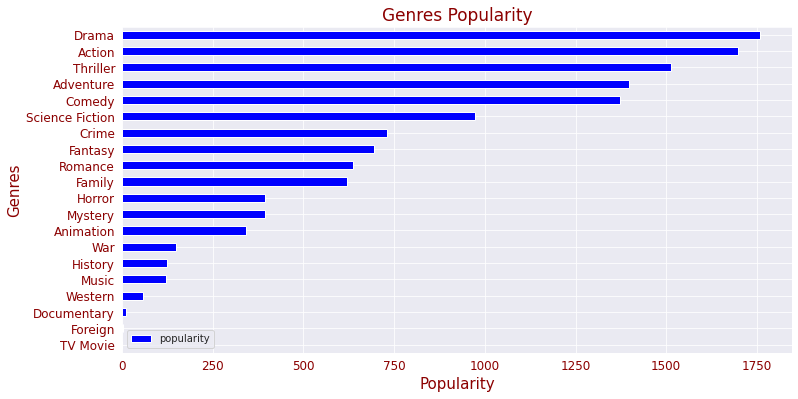

```python
#Visualizing the dataframe to show the most popular genre
#plotting a horizontal bar chart
gp = gen_pop_df.plot.barh(x='genres',y='popularity',color='Blue',figsize=(12,6))
gp.set_title('Genres Popularity', color='DarkRed', fontsize=17) #naming title
gp.set_xlabel('Popularity', color='DarkRed',fontsize=15) #naming horizotal axis
gp.set_ylabel('Genres', color='DarkRed',fontsize=15) #naming vertical axis
gp.tick_params(labelsize=12, labelcolor='DarkRed'); #setting both tick parameters
```

### 3. Monetary Analysis

> **Creating a function that calculate minimum and maximum value for a column and concatenate both and return a dataframe.**

```python
def check(col): #defining function name
    min_id = db[col].idxmin() #selecting the id of the minimum value
    min_df = pd.DataFrame(db.loc[min_id]) # selecting the row with minimum value and saving it as a dataframe
    max_id = db[col].idxmax() #selecting the id of the maximum value
    max_df = pd.DataFrame(db.loc[max_id]) #selecting the row with minimum valu and saving it as a dataframe
    min_max = pd.concat([min_df,max_df], axis =1) #joining both dataframe

    return min_max #returning the joined dataframe when the function is called
```

> **Which movie has the minimum and maximum profit**

```python
check('profit') #Checking movie with minimum and maximum profit
```

|  | 2244 | 1386 |
| --- | --- | --- |
| popularity | 0.25054 | 9.432768 |
| budget | 425000000 | 237000000 |
| revenue | 11087569 | 2781505847 |
| profit | -413912431 | 2544505847 |
| roi | -0.973912 | 10.736312 |
| original_title | The Warrior's Way | Avatar |
| cast | Kate Bosworth\|Jang Dong-gun\|Geoffrey Rush\|Dann... | Sam Worthington\|Zoe Saldana\|Sigourney Weaver\|S... |
| director | Sngmoo Lee | James Cameron |
| runtime | 100 | 162 |
| genres | Adventure\|Fantasy\|Action\|Western\|Thriller | Action\|Adventure\|Fantasy\|Science Fiction |
| release_date | 2010-12-02 00:00:00 | 2009-12-10 00:00:00 |
| vote_count | 74 | 8458 |
| vote_average | 6.4 | 7.1 |
| release_year | 2010 | 2009 |

> **Which movie has the minimum and maximum revenue**

```python
check('revenue') #checking movie with minimum and maximum revenue
```

|  | 5067 | 1386 |
| --- | --- | --- |
| popularity | 0.462609 | 9.432768 |
| budget | 6000000 | 237000000 |
| revenue | 2 | 2781505847 |
| profit | -5999998 | 2544505847 |
| roi | -1.0 | 10.736312 |
| original_title | Shattered Glass | Avatar |
| cast | Hayden Christensen\|Peter Sarsgaard\|ChloÃ« Sevi... | Sam Worthington\|Zoe Saldana\|Sigourney Weaver\|S... |
| director | Billy Ray | James Cameron |
| runtime | 94 | 162 |
| genres | Drama\|History | Action\|Adventure\|Fantasy\|Science Fiction |
| release_date | 2003-11-14 00:00:00 | 2009-12-10 00:00:00 |
| vote_count | 46 | 8458 |
| vote_average | 6.4 | 7.1 |
| release_year | 2003 | 2009 |

> **Which movie has the minimum and maximum budget**

```python
check('budget') #checking movie with minimum and maximum budget
```

|  | 2618 | 2244 |
| --- | --- | --- |
| popularity | 0.090186 | 0.25054 |
| budget | 1 | 425000000 |
| revenue | 100 | 11087569 |
| profit | 99 | -413912431 |
| roi | 99.0 | -0.973912 |
| original_title | Lost & Found | The Warrior's Way |
| cast | David Spade\|Sophie Marceau\|Ever Carradine\|Step... | Kate Bosworth\|Jang Dong-gun\|Geoffrey Rush\|Dann... |
| director | Jeff Pollack | Sngmoo Lee |
| runtime | 95 | 100 |
| genres | Comedy\|Romance | Adventure\|Fantasy\|Action\|Western\|Thriller |
| release_date | 1999-04-23 00:00:00 | 2010-12-02 00:00:00 |
| vote_count | 14 | 74 |
| vote_average | 4.8 | 6.4 |
| release_year | 1999 | 2010 |

> **Which movie has the minimum and maximum return of interest (ROI)**

```python
check('roi') #checking movie with minimum and maximim return of interest
```

|  | 10307 | 10495 |
| --- | --- | --- |
| popularity | 0.450208 | 0.772494 |
| budget | 25000000 | 113 |
| revenue | 6 | 115103979 |
| profit | -24999994 | 115103866 |
| roi | -1.0 | 1018618.283186 |
| original_title | The House of the Spirits | The Karate Kid, Part II |
| cast | Meryl Streep\|Glenn Close\|Jeremy Irons\|Winona R... | Ralph Macchio\|Pat Morita\|Martin Kove\|Charlie T... |
| director | Bille August | John G. Avildsen |
| runtime | 140 | 113 |
| genres | Romance\|Drama | Adventure\|Drama\|Action\|Romance\|Family |
| release_date | 1993-10-19 00:00:00 | 1986-06-18 00:00:00 |
| vote_count | 52 | 211 |
| vote_average | 6.7 | 5.8 |
| release_year | 1993 | 1986 |

### 4. Monetary Visuals

> **What is the relationship between Revenue, Budget and Profit**

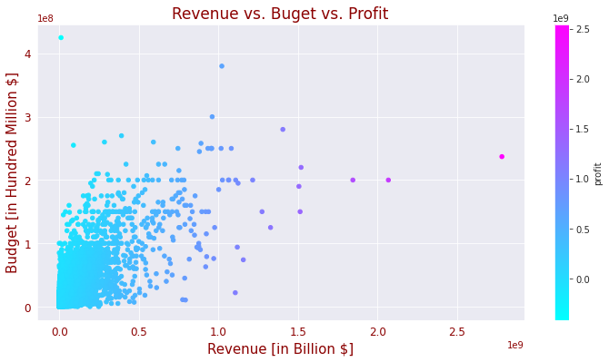

```python
#plotting a scatter plot for visual
rbp = db.plot.scatter(x='revenue', y='budget',c='profit',cmap='cool',figsize=(12,6),sharex=False)
rbp.set_title('Revenue vs. Buget vs. Profit', color='DarkRed', fontsize=17) #naming title
rbp.set_xlabel('Revenue [in Billion $]', color='DarkRed',fontsize=15) #naming horizontal axis
rbp.set_ylabel('Budget [in Hundred Million $]', color='DarkRed',fontsize=15) #naming vertical axis
rbp.tick_params(labelsize=12, labelcolor='DarkRed'); #setting tick parammeters for both axis
```

> The plot above shows how budget and revenue contributes to profit.

> **What is the relationship between Revenue and Profit**

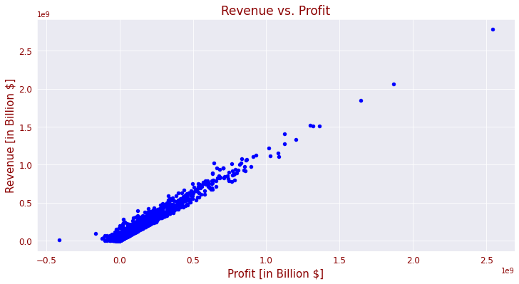

```python
#plotting a scatter plot for visual
rp = db.plot.scatter(x='profit', y='revenue',c='Blue',figsize=(12,6),sharex=False)
rp.set_title('Revenue vs. Profit', color='DarkRed', fontsize=17) #naming title
rp.set_xlabel('Profit [in Billion $]', color='DarkRed',fontsize=15) #naming horizontal axis
rp.set_ylabel('Revenue [in Billion $]', color='DarkRed',fontsize=15) #naming vertical axis
rp.tick_params(labelsize=12, labelcolor='DarkRed'); #setting tick parammeters for both axis
```

> **What is the relationship between Budget and Profit**

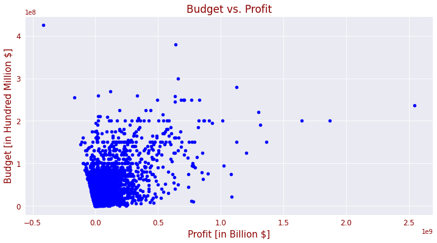

```python
#plotting a scatter plot for visual
bp = db.plot.scatter(x='profit', y='budget',c='Blue',figsize=(12,6),sharex=False)
bp.set_title('Budget vs. Profit', color='DarkRed', fontsize=17) #naming title
bp.set_xlabel('Profit [in Billion $]', color='DarkRed',fontsize=15) #naming horizontal axis
bp.set_ylabel('Budget [in Hundred Million $]', color='DarkRed',fontsize=15) #naming vertical axis
bp.tick_params(labelsize=12, labelcolor='DarkRed'); #setting tick parammeters for both axis
```

> The plot above shows that the profit earned from a movie does not depend on the budget amount.

> **Which month has the highest profit from movie**

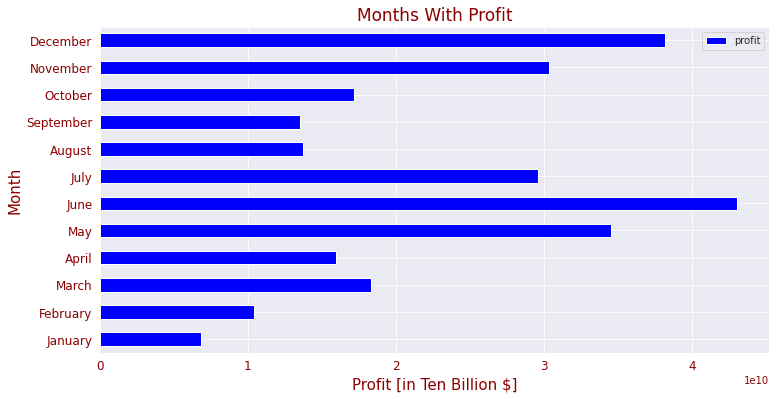

```python
# remember 'dbv1' the dataframe with release_date as its index, it will be used here

# selecting sum of profit grouped by month
month_prft = dbv1.groupby(dbv1.index.month)['profit'].sum()
month_prft = pd.DataFrame(month_prft) #converting the series above to a dataframe

#plotting horizontal bar chart for visual
mp= month_prft.plot.barh(y='profit',color='Blue',figsize=(12,6))
mp.set_title('Months With Profit', color='DarkRed',fontsize=17) #naming title
mp.set_xlabel('Profit [in Ten Billion $]',color='DarkRed', fontsize=15) #naming horizontal axis
mp.set_ylabel('Month', color='DarkRed', fontsize=15) #naming vertical axis
mp.tick_params(labelsize=12, labelcolor='DarkRed') #setting tick parameters for both axis
mp.set_yticklabels(month_names,); #naming vertical ticks with month names
```

> December and June is the month with most profit. Why is that? Is it because of the number of movies produced in that month? Let's find out!

> **Which month has more movie produced**

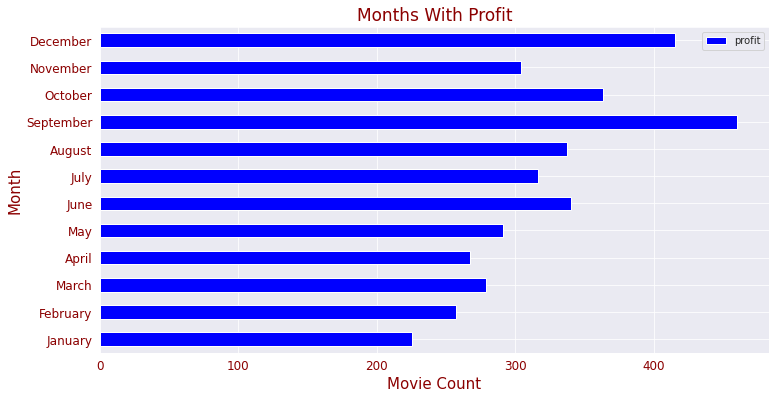

```python
# selecting count of profit grouped by month
mnth_prft_count = dbv1.groupby(dbv1.index.month)['profit'].count()
mnth_prft_count = pd.DataFrame(mnth_prft_count)
#plotting horizontal bar chart for visual
mpc= mnth_prft_count.plot.barh(y='profit',color='Blue',figsize=(12,6))
mpc.set_title('Months With Profit', color='DarkRed',fontsize=17) #naming title
mpc.set_xlabel('Movie Count',color='DarkRed', fontsize=15) #naming horizontal axis
mpc.set_ylabel('Month', color='DarkRed', fontsize=15) #naming vertical axis
mpc.tick_params(labelsize=12, labelcolor='DarkRed') #setting tick parameters for both axis
mpc.set_yticklabels(month_names,); #naming vertical ticks with month names
```

> Wow! We can see from the chart above that number of movie produced in a month does not define how much profit will be made for that month. September has the highest count of movies yet its one of the month with smaller profit. June which had the highest profit is not among the top three month with highest movie count.

> **What is the relationship between Runtime vs Profit**

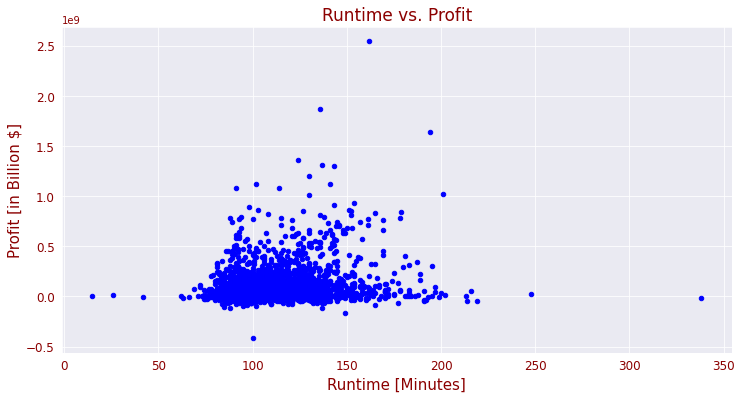

```python
#plotting a scatter plot for visual
rtp = db.plot.scatter(x='runtime', y='profit',c='Blue',figsize=(12,6),sharex=False)
rtp.set_title('Runtime vs. Profit', color='DarkRed', fontsize=17) #naming title
rtp.set_xlabel('Runtime [Minutes]', color='DarkRed',fontsize=15) #naming horizontal axis
rtp.set_ylabel('Profit [in Billion $]', color='DarkRed',fontsize=15) #naming vertical axis
rtp.tick_params(labelsize=12, labelcolor='DarkRed',); #setting tick parammeters for both axis
```

> The chart above shows how much is earned for a lenght of movie. Movie that runs for 100 to 150 minutes generates much profit.

> **7. Top Budget Movie**

```python
mbr = db.loc[:,['original_title','budget','revenue']] #selecting movie name,budget and revenue column
mbr.head(3) #previewing
```

|  | original_title | budget | revenue |
| --- | --- | --- | --- |
| 0 | Jurassic World | 150000000 | 1513528810 |
| 1 | Mad Max: Fury Road | 150000000 | 378436354 |
| 2 | Insurgent | 110000000 | 295238201 |

```python
#function that returns a dataframe sorted by the given column
def slice(col): # defining function
    mbr.sort_values(by=col,ascending=False,inplace=True) # sort dataframe by specific column in descending order
    mbr.reset_index(inplace=True,drop=True) #rearrange the index after sorting
    ten_row = mbr.iloc[0:10,:] #select the first ten row of the column
    srtd_ten_row = ten_row.copy() #make a copy for sorting
    srtd_ten_row.sort_values(by=col,inplace=True) #sort the column in ascending order for plotting
    srtd_ten_row.reset_index(inplace=True,drop=True) #reset the index for good arrangement in disaplay
    return srtd_ten_row #return a sorted dataframe when the function is called
```

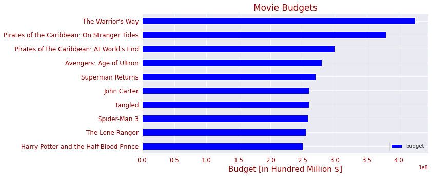

```python
# calling the function to create the top 10 movie with high budget
mov_bud = slice('budget')

#Visualizing the dataframe to show the most budget movie
#plotting a horizontal bar chart
mb = mov_bud.plot.barh(x='original_title',y='budget',color='Blue',figsize=(10,5))
mb.set_title('Movie Budgets', color='DarkRed', fontsize=17) #naming title
mb.set_xlabel('Budget [in Hundred Million $]', color='DarkRed',fontsize=15) #naming horizotal axis
mb.set_ylabel('') #naming vertical axis
mb.tick_params(labelsize=12, labelcolor='DarkRed'); #setting both tick parameters
```

> The above charts display the first 10 movies with high budget.

> **8. Top Revenue Movie**

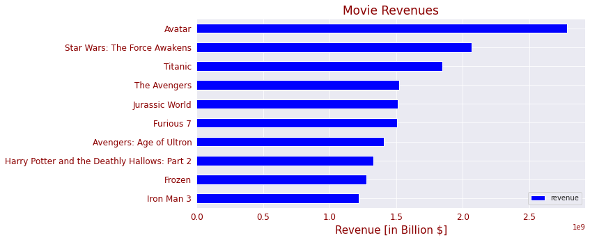

```python
# calling the function to create the top 10 movie with high revenue
mov_rev = slice('revenue')

#Visualizing the dataframe to show the most popular genre
#plotting a horizontal bar chart
mr = mov_rev.plot.barh(x='original_title',y='revenue',color='Blue',figsize=(10,5))
mr.set_title('Movie Revenues', color='DarkRed', fontsize=17) #naming title
mr.set_xlabel('Revenue [in Billion $]', color='DarkRed',fontsize=15) #naming horizotal axis
mr.set_ylabel('') #naming vertical axis
mr.tick_params(labelsize=12, labelcolor='DarkRed'); #setting both tick parameters
```

## Conclusions

**Limitation**

> This analysis was done based on assuption that the currency is in dollars, because the dataset did not specify which currency. Also some movies could have been produced in different countries and this would mean havig budget and revenue of different curencies. Also while making the analysis some rows were dropped, such as that of revenue and budget which affected the analysis.